# GPCA Metrics: Building M and A

This vignette collects practical recipes for row and column metrics, plus notes on SPD remedies and the experimental `gpca_mle()` learner.

## Why metrics

Metrics encode weighting and correlation. The row metric `M` changes how observations are compared; the column metric `A` changes how variables are compared. Setting either to something other than the identity is how you tell the decomposition what you already know about the data: that the samples are a time series, that the variables sit on a spatial grid or fall into groups, that some measurements are noisier than others. Ordinary PCA has no way to accept that information and treats every row and column alike. GPCA writes it into the objective being optimised.

Structure alone is not enough, though: you also have to get the *direction* right, and supplying a matrix versus its inverse produces opposite results. The next section is about that, and it is worth reading before the recipes.

Both metrics must also be symmetric and positive semi-definite. That rarely gets in the way, but it does constrain what you can pass; see SPD requirements and remedies below for what the requirement means and what `genpca()` does when a metric falls short of it.

## Heteroscedastic diagonals

The simplest non-trivial metric is a diagonal that down-weights noisy rows or columns:

```r
set.seed(42)
n <- 60; p <- 20
X <- matrix(rnorm(n * p), n, p)

col_noise_sd <- runif(p, 0.5, 2)
A <- Diagonal(x = 1 / col_noise_sd^2)
row_noise_sd <- runif(n, 0.7, 1.3)
M <- Diagonal(x = 1 / row_noise_sd^2)

fit <- genpca(X, M = M, A = A, ncomp = 3,
              preproc = multivarious::center())
fit$sdev
```

```
#> [1] 14.69818 11.24551 10.96887
```

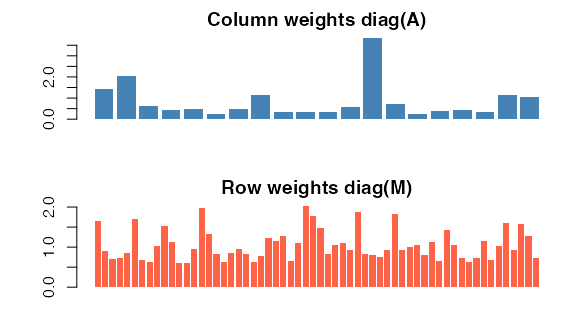

Inverse-variance weights on columns (top) and rows (bottom). Noisier dimensions get smaller weights.

### Inverse column variance *is* scaled PCA

Inverse-variance weighting on the columns is not a new idea in disguise: it is exactly the standardisation that `prcomp(scale. = TRUE)` performs. GPCA whitens with the square root $A^{1/2}$, so setting $A = \operatorname{diag}(1/s_j^2)$ makes $X A^{1/2} = X \operatorname{diag}(1/s_j)$ — the column-scaled matrix that correlation-matrix PCA decomposes.

```r
set.seed(42)
Xv <- matrix(rnorm(60 * 20), 60, 20) %*% diag(runif(20, 0.5, 3))
sds <- apply(Xv, 2, sd)

g  <- genpca(Xv, A = Diagonal(x = 1 / sds^2), ncomp = 5,
             preproc = multivarious::center())
pr <- prcomp(Xv, scale. = TRUE)

# scores agree component by component
sapply(1:3, function(k) cor(multivarious::scores(g)[, k], pr$x[, k]))
```

```
#> [1] -1 -1 -1
```

The scores are identical (up to sign). The reported `sdev` values differ by a single constant, because `prcomp()` divides its singular values by $\sqrt{n-1}$ and `genpca()` reports them unnormalised:

```r
rbind(genpca = g$sdev[1:5],
      prcomp = pr$sdev[1:5],
      ratio  = g$sdev[1:5] / pr$sdev[1:5])
```

```
#>             [,1]      [,2]      [,3]     [,4]     [,5]
#> genpca 11.527935 10.943470 10.310907 9.651052 9.172200
#> prcomp  1.500809  1.424718  1.342366 1.256460 1.194119
#> ratio   7.681146  7.681146  7.681146 7.681146 7.681146
```

```r
sqrt(nrow(Xv) - 1)
```

```
#> [1] 7.681146
```

The constant ratio is the whole difference. This is worth internalising as the baseline: **a diagonal `A` generalises column scaling**, and everything else in this vignette — kernels, Laplacians, AR(1) structure — generalises it further by letting the metric go off-diagonal.

### Weighting both margins at once

The example above sets `M` and `A` simultaneously, which is a reasonable thing to want when both observations and variables are heteroscedastic. Two consequences are easy to miss.

**The two weightings interact.** GPCA works with $M^{1/2} X A^{1/2}$, so the row weights change each column’s effective variance and the column weights change each row’s. Estimating row and column standard deviations from the raw data and applying both at once therefore standardises *neither* margin:

```r
Xc <- scale(Xv, center = TRUE, scale = FALSE)
W  <- diag(1 / apply(Xc, 1, sd)) %*% Xc %*% diag(1 / apply(Xc, 2, sd))

range(apply(W, 1, sd))   # row SDs, would be constant if standardised
```

```
#> [1] 0.4075883 0.6182529
```

```r
range(apply(W, 2, sd))   # column SDs
```

```
#> [1] 0.4740343 0.5317369
```

Each rescaling changes the other margin’s standard deviations, so one pass does not produce unit variance on both. Alternating marginal scaling is a separate procedure from `gpca_mle()`: that learner alternates a low-rank fit with estimates of the full residual row and column covariances, including a ridge penalty. It does not simply standardize the two margins.

**Only the product of the two scales is identified.** Replacing $(M, A)$ with $(cM, A/c)$ leaves $M^{1/2} X A^{1/2}$ untouched, so the fit cannot distinguish them:

```r
M0 <- Diagonal(x = 1 / apply(Xv, 1, sd)^2)
A0 <- Diagonal(x = 1 / sds^2)

f1 <- genpca(Xv, M = M0,     A = A0,     ncomp = 4, preproc = multivarious::center())
f2 <- genpca(Xv, M = 7 * M0, A = A0 / 7, ncomp = 4, preproc = multivarious::center())

max(abs(f1$sdev - f2$sdev))
```

```
#> [1] 2.664535e-15
```

The singular values and the component subspace are identical; only the scores pick up a constant factor, since their normalisation is tied to the scale of `M`. The practical upshot is that there is no point tuning the overall magnitude of `M` against that of `A` — it is the *relative* weighting within each metric that changes the answer. This indeterminacy is also why `gpca_mle()` has a `scale_fix` argument: when both metrics are learned, the split is pinned down by the ridge penalty in the objective (the default, `scale_fix = "none"`), and `"trace"`/`"det"` are optional post-hoc reparameterizations whose effect on the penalized objective is reported in `loglik_rescale_delta`.

## Which way does a metric point?

Before the recipes, the single most important thing to get right — and the easiest to get backwards. **A metric amplifies its own dominant eigendirections.**

Seeing why means being precise about what comes back from a fit. GPCA factorises $X \approx U D V^{\top}$, where $V$ is orthonormal *in the column metric* rather than in the ordinary sense: $V^{\top} A V = I$. The loadings returned by `components(fit)` are not $V$ but $AV$:

```r
set.seed(1)
Xd <- matrix(rnorm(400), 40, 10)
Ad <- crossprod(matrix(rnorm(100), 10, 10)) / 10 + diag(10)
fd <- genpca(Xd, A = Ad, ncomp = 3, preproc = multivarious::center())

max(abs(multivarious::components(fd) - as.matrix(Ad %*% fd$ov)))
```

```
#> [1] 0
```

Multiplication by $A$ changes how the fitted factor is expressed. It stretches every direction in proportion to the eigenvalue $A$ assigns it, so the patterns $A$ scores highly are the patterns that dominate the loadings you read off. (The bare factor $V$ is kept in the `ov` slot if you ever need it, but `components()` is what you should normally interpret.)

For a spatial or temporal structure there are two natural matrices, and they point in *opposite* directions:

| You supply | $v^{\top}Av$ measures | Large eigenvalues on | Components come out |
| --- | --- | --- | --- |
| A **smoother**: kernel $K$, adjacency $I + \alpha W$, $(I+\alpha L)^{-1}$, heat kernel $e^{-tL}$ | agreement between neighbours | smooth patterns | **smoother** |
| A **precision**: Laplacian $L$, $I + \alpha L$, $K^{-1}$, inverse AR(1) | disagreement across edges (Dirichlet energy $\sum_{i\sim j}(v_i - v_j)^2$) | rough patterns | **rougher** |

Both are legitimate, because they encode different beliefs about *where the noise lives*. The bridge is $A = \Sigma_{\text{col}}^{-1}$, and the step that is easy to skip is the inversion: the metric and the noise covariance share eigenvectors but carry **reciprocal** weights, so a direction the metric scores highly is a direction the noise model calls quiet.

That reciprocal is worth seeing rather than taking on faith. On a cycle graph the Laplacian and the adjacency share Fourier eigenvectors exactly, so “roughness” is unambiguously frequency:

```r
p <- 32
Wc <- matrix(0, p, p)
for (i in 1:p) { Wc[i, i %% p + 1] <- 1; Wc[i %% p + 1, i] <- 1 }
Lc <- diag(rowSums(Wc)) - Wc

ec <- eigen(Lc, symmetric = TRUE)
o  <- order(ec$values)
Vc <- ec$vectors[, o]          # smoothest first
lc <- ec$values[o]             # Dirichlet energy = roughness

Ac  <- diag(p) + 0.45 * Wc     # a smoother (PSD)
Sig <- solve(Ac)               # the noise covariance it implies

modes <- c(1, 16, 32)          # smoothest, middling, roughest
data.frame(
  roughness   = round(lc[modes], 3),
  metric_wt   = round(sapply(modes, function(k) t(Vc[, k]) %*% Ac  %*% Vc[, k]), 3),
  noise_var   = round(sapply(modes, function(k) t(Vc[, k]) %*% Sig %*% Vc[, k]), 3)
)
```

```
#>   roughness metric_wt noise_var
#> 1         0       1.9     0.526
#> 2         2       1.0     1.000
#> 3         4       0.1    10.000
```

The metric weight *falls* with roughness while the implied noise variance *rises*, each the reciprocal of the other. Note this is a statement about $\Sigma_{\text{col}} = A^{-1}$, not about the adjacency matrix you supplied: $A$ itself has its large eigenvalues on the **smooth** directions. Inverting is what moves the variance to the rough end.

- **Smoother as metric** $\Rightarrow$ $A$ is large on smooth directions $\Rightarrow$ $\Sigma_{\text{col}} = A^{-1}$ is large on the rough ones $\Rightarrow$ “the noise is high-frequency speckle; the signal is smooth.” This is denoising, and it is what you want when you are after spatially coherent maps.
- **Precision as metric** $\Rightarrow$ $A$ is large on rough directions $\Rightarrow$ $\Sigma_{\text{col}}$ is large on the smooth ones $\Rightarrow$ “a smooth field — drift, a scanner gradient, a global trend — is the nuisance.” Whitening it away lets fine-scale structure surface. This is ordinary generalized least squares against correlated noise.

One caveat on how literally to read this. $A = \Sigma_{\text{col}}^{-1}$ is an interpretive frame, not a constraint `genpca()` enforces — the algorithm only ever whitens with $A^{1/2}$. The covariance reading is how you should *choose* a metric, and it is what makes “smoother $\Rightarrow$ denoising” more than a slogan.

So the question is never “adjacency or Laplacian?” in the abstract. It is: **is the smooth thing my signal, or my nuisance?**

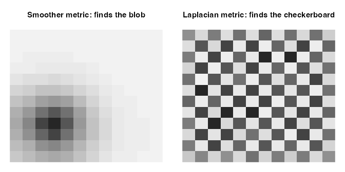

The same graph, two metrics. Left: a smoother concentrates PC1 on the smooth blob. Right: the Laplacian whitens the smooth field away, so PC1 locks onto the fine-scale checkerboard that was buried underneath it.

Two practical notes on the graph matrices themselves. A raw adjacency $W$ is **indefinite** (its eigenvalues sum to zero), so it is not a valid metric on its own — shift it, as in $I + \alpha W$ with $\alpha$ small enough to keep it PSD. A raw Laplacian $L$ is PSD but **singular**: $L\mathbf{1} = 0$, so the spatially constant pattern has zero length under it. `genpca()` accepts that (the whitening uses a pseudo-inverse), but adding a small ridge, $L + \varepsilon I$, is usually what you want.

The example compares a smoother with coefficient 2 against a precision with coefficient 50. It demonstrates these two choices, not a universal switching threshold. Sweep the strength on your own data and inspect the loadings.

## Recipes

Each recipe below is labelled with the direction it produces. All three are written as **precision** matrices. For the AR(1) and RBF recipes, use the covariance inside `solve()` to obtain the smoother orientation. The Laplacian recipe constructs a precision directly; invert its regularized matrix to obtain a smoother.

### AR(1) row metric (whitens temporal autocorrelation)

Standard GLS treatment of serially correlated observations, as in fMRI prewhitening: it removes temporal autocorrelation rather than imposing temporal smoothness.

```r
rho     <- 0.7
n_t     <- 60
idx     <- 0:(n_t - 1)
Sigma_r <- outer(idx, idx, function(i, j) rho^abs(i - j))
M_ar1   <- solve(Sigma_r + 1e-3 * diag(n_t))
```

### Spatial RBF kernel (whitens smooth spatial noise)

```r
coords <- as.matrix(expand.grid(x = 1:8, y = 1:8))
d2     <- as.matrix(dist(coords))^2
ell    <- 2
K      <- exp(-d2 / (2 * ell^2))
A_rbf  <- solve(K + 1e-3 * diag(nrow(K)))   # precision: emphasises fine scale
# A_smooth <- K + 1e-3 * diag(nrow(K))      # kernel itself: smooth loadings
```

### Graph Laplacian (emphasises contrast across edges)

```r
W <- bandSparse(30, k = c(-1, 0, 1),
                diagonals = list(rep(0.2, 29),
                                 rep(1, 30),
                                 rep(0.2, 29)))
D     <- Diagonal(x = rowSums(W))
A_lap <- (D - W) + 1e-2 * Diagonal(nrow(W))
# A_smooth <- solve(A_lap)                  # smoother: spatially coherent loadings
```

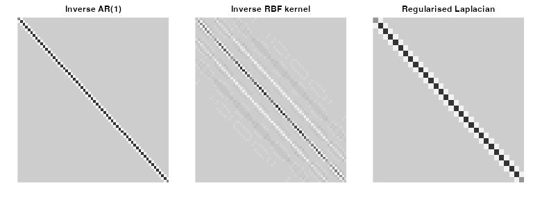

Three structured metrics, all shown in the precision (noise-whitening) orientation. Off-diagonal banding is what couples nearby rows or variables – it tells GPCA ‘treat these dimensions as related, not independent’.

### A note on `sfpca()`

`sfpca()` takes the *opposite* input for the same intent. There the structure enters as a constraint, $v^{\top}(I + \alpha\Omega)v \le 1$, which charges rough $v$ against a fixed budget — so the spatial roughness operator is built from `spat_cds`, and `alpha_v` controls its strength. Larger `alpha_v` means **smoother**; it is a scalar, not an argument for supplying a matrix. Metric form and constraint form are inverse to one another: the same Laplacian smooths in `sfpca()` and roughens in `genpca()`.

## Learning metrics with `gpca_mle()`

`gpca_mle()` is an experimental learner that alternates a low-rank fit with regularized matrix-normal covariance estimates. Use it to explore estimated metrics, checking their spectra and sensitivity to the ridge parameter `lambda`. An i.i.d. input does not guarantee an identity-like fitted metric: a single small data matrix provides limited information about unrestricted row and column covariances, especially after fitting a low-rank mean.

```r
set.seed(1)
n_m <- 40; p_m <- 10
X_mle <- matrix(rnorm(n_m * p_m), n_m, p_m)
fit_mle <- gpca_mle(X_mle, ncomp = 2, max_iter = 6,
                    lambda = 1e-3, scale_fix = "none",
                    method = "eigen", verbose = FALSE)

metric_spectrum <- function(W) {
  ev <- eigen(as.matrix(W), symmetric = TRUE, only.values = TRUE)$values
  c(min = min(ev), max = max(ev), condition = max(ev) / min(ev))
}
signif(rbind(M = metric_spectrum(fit_mle$M),
             A = metric_spectrum(fit_mle$A)), 3)
```

```
#>        min  max condition
#> M 4.27e-04 1000  2.34e+06
#> A 6.34e+02 1000  1.58e+00
```

The row metric has widely separated eigenvalues. A heatmap can look nearly diagonal while hiding this distinction, so plot the spectrum after removing overall scale. An identity-like metric would have every normalized eigenvalue near one.

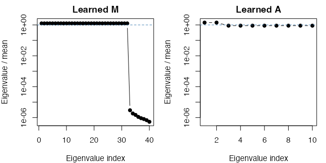

Metric eigenvalues divided by their mean, on a log scale. The dashed line marks an identity-like spectrum; the learned row metric departs strongly from it.

Inspect optimization progress as well:

```r
data.frame(iteration = seq_along(fit_mle$loglik_path),
           penalized_loglik = fit_mle$loglik_path)
```

```
#>   iteration penalized_loglik
#> 1         1         1204.753
#> 2         2         1368.764
#> 3         3         1526.016
#> 4         4         1660.870
#> 5         5         1744.850
#> 6         6         1773.051
```

Six iterations are an illustration, not evidence of convergence or covariance recovery. Keep `lambda` positive and compare results across its plausible values. The default `scale_fix = "none"` retains the scale selected by the penalized fit; optional `"trace"` or `"det"` rescaling changes the penalized objective, reported in `loglik_rescale_delta`. The separate `loglik_refit_delta` records the remaining difference between the last iteration’s objective and the returned objective, including the final refit and numerical reevaluation. With `scale_fix = "none"`, the rescale delta is exactly zero even when the refit delta is nonzero.

## SPD requirements and remedies

### Why the requirement exists

GPCA measures squared lengths using $u^\top M u$ and $v^\top A v$, and the solvers whiten the data with the square roots $M^{1/2}$ and $A^{1/2}$. Both steps need the metrics to be symmetric positive semi-definite (PSD). If a metric has a negative eigenvalue, vectors in that direction have negative squared length, the square root is not real, and “maximise variance” no longer picks out anything meaningful.

Note that *semi*-definite is enough. **Singular metrics are perfectly legal.** A graph Laplacian is rank-deficient by construction — it has a zero eigenvalue on the constant vector — and `genpca()` takes it without complaint. A zero eigenvalue simply means that direction is given no weight. Only *negative* eigenvalues are a problem.

### What happens when a metric falls short

Distinguish singularity from invalidity: a sample covariance from fewer samples than variables can be singular and still PSD. Rounding can produce small negative eigenvalues or slight asymmetry; an incorrectly constructed metric can produce larger violations. The checks are relative to the scale of the matrix, with a tolerance for floating-point noise: eigenvalues down to $-\sqrt{\epsilon}\,\max|A_{ii}|$ (about $-1.5\times10^{-8}$ times the largest diagonal entry) count as non-negative, and an asymmetry $\|A - A^\top\|_F / \|A\|_F$ below $10^{-10}$ is averaged away. Tiny asymmetry may therefore be averaged away; metric factorization also uses numerical tolerances to identify null directions. An explicit `"clip"` request removes negative eigenvalues even if they pass the tolerant PSD check.

A genuinely asymmetric matrix is an error under every setting: there is no way to know which triangle you meant. And a metric that fails the PSD check is an error by default (`constraints_remedy = "error"`), because a fit that silently ran on a different metric than the one you supplied is worse than no fit. If you do want a repair, ask for it, and you will be told what was done:

| Value | What it does | What it costs |
| --- | --- | --- |
| `"error"` (default) | Refuses the input. | Nothing — this is the right setting when the metric comes from a pipeline that ought to be producing a valid one. |
| `"ridge"` | Adds a diagonal shift (from the Gershgorin bound, with a `Matrix::nearPD()` fallback for small dense matrices) sufficient to make the matrix positive definite. Preserves sparsity. | The shift pulls the metric toward a multiple of the identity, diluting the structure you supplied. A *large* shift means the input was badly indefinite — diagnose it rather than absorb it. |
| `"clip"` | Eigendecomposes and sets the negative eigenvalues to zero, leaving the rest of the spectrum exactly as it was. | Densifies the matrix, so it refuses sparse input larger than 2000×2000. Use `"ridge"` at that size. |
| `"identity"` | Replaces the offending metric with the identity. | Discards the offending metric; the other metric still applies. |

Every repair that actually changes the metric emits a warning of class `genpca_metric_repaired` whose `report` field records the minimum eigenvalue before and after, the shift applied, the rank and the condition number. The same report is available directly from `repair_metric()`, which is the better way to work: repair once, look at the report, and pass the repaired matrix to every subsequent fit.

```r
# Is the metric usable as-is, and what would a repair do to it?
A_ok <- repair_metric(A, method = "ridge")
attr(A_ok, "repair_report")

# Catch the repair warning programmatically inside a fit
fit <- withCallingHandlers(
  genpca(X, A = A, M = M, ncomp = 3, constraints_remedy = "ridge"),
  genpca_metric_repaired = function(w) { print(w$report); invokeRestart("muffleWarning") }
)
```

Prefer metrics that are PSD by construction, such as a PSD kernel, a graph Laplacian, or a nonnegative diagonal. Dividing a metric by its mean diagonal changes its overall magnitude but leaves its condition number unchanged. Inspect the repair report when a repair is requested, and inspect learned metric spectra even when no warning is emitted.

## Where next

See Modelling Structured Noise for how to choose the transfer function when several kinds of structure are present at once, and GPCA at Scale for backend choices, sparse workflows, and covariance-only GPCA.